# Preclearance Is Not Just For Flights

Fulton Jackson, Eion Blanchard

Last updated on 2019-05-30

```r
# Step 0: Setup
# Load relevant libraries
#data analysis
library(xlsx)
library(tidyverse)
library(stringr)
library(plyr)
library(dplyr)
library(readr)
#mapping
library(ggplot2)

# Initialize constants
STATES <- c("Alabama", "Alaska", "Arizona", "Arkansas", "California", "Colorado", "Connecticut", "Delaware", "Florida", "Georgia", "Hawaii", "Idaho", "Illinois", "Indiana", "Iowa", "Kansas", "Kentucky", "Louisiana", "Maine", "Maryland", "Massachusetts", "Michigan", "Minnesota", "Mississippi", "Missouri", "Montana", "Nebraska", "Nevada", "New Hampshire", "New Jersey", "New Mexico", "New York", "North Carolina", "North Dakota", "Ohio", "Oklahoma", "Oregon", "Pennsylvania", "Rhode Island", "South Carolina", "South Dakota", "Tennessee", "Texas", "Utah", "Vermont", "Virginia", "Washington", "West Virginia", "Wisconsin", "Wyoming")
```

### Background

The Voting Rights Act of 1965 is a piece of federal legislation that prohibits racial discrimination in regards to voting. Section 5 of the Voting Rights Act prohibits certain jurisdictions from implementing any change affecting voting without receiving preclearance from either the U.S. Attorney General or the U.S. District Court. In this project, we looked at the frequency with which jurisdictions submitted change provisions, their reasons, and which types were most common. We examined weekly data as reported on the Justice Department website from September 2010 to July 2012. We aggregated the posted data sheets into a single set and encoded the change types. When change descriptions overlapped, we applied a common numerical code.

### Question

What types of preclearence requests are states submitting each month? What percentage is the proportion of each request? What sort of factors indicate a request for redistricting?

### Datasets

- Notices of Section 5 activity under the Voting Rights Act of 1965, as amended
  - Link: https://www.justice.gov/crt/archive-notices-section-5-activity-under-voting-rights-act-1965-amended
  - Used data for September 27, 2010 to July 30, 2012
  - Employed .xls version
  - Noticing state, county, and subjurisdiction logged alongside:
    - submission ID
    - action date
    - changes enacted

```r
# Step 2: Import and clean the data
read_and_tidy <- function(fileName) {
  file_messy <- read.xlsx(fileName, sheetName = "Sheet1")
  file <- file_messy %>%
    select(1, 4, 7, 11, 15, 18, 21, 25) %>%
    unite(NA..23, NA..23, NA..19) %>%
    dplyr::rename(state = NA.,
                  county = NA..3,
                  subjurisdiction = NA..5,
                  submission = NA..9,
                  action_date = NA..13,
                  action = NA..16,
                  changes = NA..23) %>%
    filter(state %in% STATES) %>%
    mutate(action_date = as.Date(action_date, "%m/%d/%Y"),
           changes = str_replace(changes, "_NA", ""),
           changes = str_replace(changes, "NA_", ""))

  levels <- levels(file$county)
  levels[length(levels) + 1] <- "None"
  file$county <- factor(file$county, levels = levels)
  file$county[is.na(file$county)] <- "None"
  levels <- levels(file$subjurisdiction)
  levels[length(levels) + 1] <- "None"
  file$subjurisdiction <- factor(file$subjurisdiction, levels = levels)
  file$subjurisdiction[is.na(file$subjurisdiction)] <- "None"
  return(file)
}
```

### Graphic

Below, we plot the preclearance notice changes and their trends in frequency.

```
## # A tibble: 183 x 5
## # Groups:   date [23]
##    date   code     n xwidth month
##    <chr> <dbl> <dbl>  <dbl> <fct>
##  1 10 09     1    24    457 Sep '10
##  2 10 09     2   168    457 Sep '10
##  3 10 09     3    92    457 Sep '10
##  4 10 09     4    77    457 Sep '10
##  5 10 09     5    17    457 Sep '10
##  6 10 09     6    44    457 Sep '10
##  7 10 09     7     5    457 Sep '10
##  8 10 09     8    30    457 Sep '10
##  9 10 10     1    23    831 Oct '10
## 10 10 10     2   273    831 Oct '10
## # … with 173 more rows
```

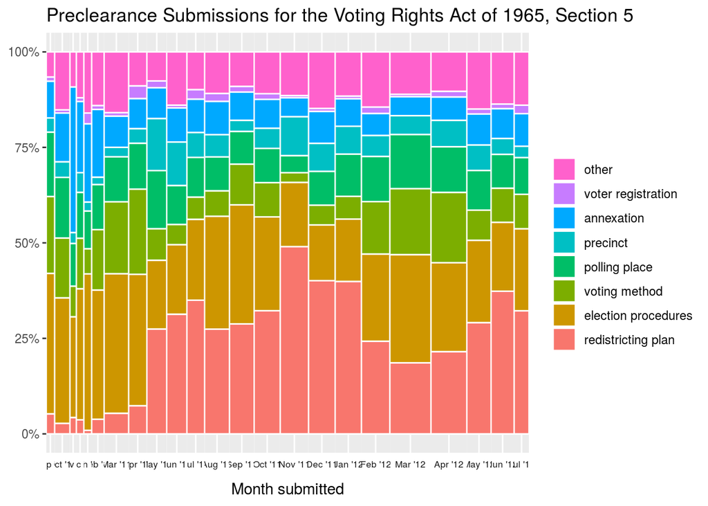

```r
# Step 5: Plot mosaics of change notices
#employ only ggplot2, not ggmosaic
#prepare the data for national plotting
data_p <- data %>%
  mutate(date = format(action_date, "%y %m")) %>%
  group_by(date, code) %>%
  dplyr::summarize(s = sum(code)) %>%
  mutate(n = s / code) %>% # assumes that code values are nonzero
  select(-s)
widths <- data_p %>%
  group_by(date) %>%
  dplyr::summarize(xwidth = sum(n))
data_p <- data_p %>%
  left_join(widths, by = "date") %>%
  mutate(month = format(as.Date(paste(date, "01", sep = " "), "%Y %m %d"), "%b '%y"))
data_p$month = factor(data_p$month,
                      levels=c("Sep '10", "Oct '10", "Nov '10", "Dec '10",
                               "Jan '11", "Feb '11", "Mar '11", "Apr '11", "May '11", "Jun '11",
                               "Jul '11", "Aug '11", "Sep '11", "Oct '11", "Nov '11", "Dec '11",
                               "Jan '12", "Feb '12", "Mar '12", "Apr '12", "May '12", "Jun '12", "Jul '12"))
#plot the mosaic for combined national counts
data_p %>%
  print()%>%
  ggplot(aes(x = factor(month), y = n)) +
  geom_col(aes(width = xwidth,
               fill = factor(code)),
           colour = "white",
           size = .5,
           position = position_fill(reverse = TRUE)) +
  facet_grid(~ month, space = "free", scales = "free", switch = "x") +
  scale_x_discrete(name = "Month submitted") +
  scale_y_continuous(labels = scales::percent) +
  theme(strip.text.x = element_text(size = 6.5, angle = 0),
        axis.text.x = element_blank(),
        axis.ticks.x = element_blank(),
        axis.title.y = element_blank(),
        strip.background = element_blank(),
        panel.spacing = unit(0, "pt")) +
  scale_fill_discrete(name = "",
                      breaks = c("1", "2", "3", "4", "5", "6", "7", "8"),
                      labels = c("redistricting plan", "election procedures", "voting method", "polling place", "precinct", "annexation", "voter registration", "other"),
                      guide = guide_legend(reverse=TRUE)) +
  labs(title = "Preclearance Submissions for the Voting Rights Act of 1965, Section 5")
```

```r
# Step 6: Modelling trends in the preclearance change notices
#prepare data for regression
data_t <- data_p %>%
  select(-xwidth) %>%
  spread(key = code, value = n) %>%
  dplyr::rename(redistricting = 3, election = 4, method = 5, polling = 6, precinct = 7, annex = 8, registration = 9, other = 10)
data_t[is.na(data_t)] <- 0
```

```r
#model redistricting notices in terms of precinct notices
model <- glm(formula = redistricting ~ precinct, data = data_t)
summary(model)
```

```
##
## Call:
## glm(formula = redistricting ~ precinct, data = data_t)
##
## Deviance Residuals:
##     Min       1Q   Median       3Q      Max
## -285.23   -95.25   -28.79   135.11   237.07
##
## Coefficients:
##             Estimate Std. Error t value Pr(>|t|)
## (Intercept)  39.1884    51.1425   0.766    0.452
## precinct      3.6873     0.6237   5.912 7.21e-06 ***
## ---
## Signif. codes:  0 '***' 0.001 '**' 0.01 '*' 0.05 '.' 0.1 ' ' 1
##
## (Dispersion parameter for gaussian family taken to be 18735.48)
##
##     Null deviance: 1048314  on 22  degrees of freedom
## Residual deviance:  393445  on 21  degrees of freedom
## AIC: 295.46
##
## Number of Fisher Scoring iterations: 2
```

```r
# plot(redistricting ~ precinct, data = data_t)
# abline(model)

# data_t %>%
#   ggplot(aes(y = 'redistricting', x = precinct)) +
#   geom_point(alpha = 0.3) +
#   labs(y = "Count of redistricting notices", x = "Count of precinct notices") +
#   geom_smooth(method = "lm", se = FALSE)
```

A solid relationship exists between the count of redistricting notices and the count of precinct change notices, by month. This makes intuitive sense, since redistricting plans often included modified precincts in order to satisfy the “one person, one vote” population stipulation.